# WUM - Projekt 1 - finalne modele, prezentacja rezultatów

Konrad Komisarczyk, Patryk Wrona

21 kwietnia 2020

# Ładowanie danych i przygotowywanie

Usuwamy kolumny, o których stwierdziliśmy na poprzednich kamieniach milowych, że są nadmiarowe:

```r
data <- read.csv("cervical-cancer_csv.csv")

factorize <- function(data, indices) {
  for (i in indices) {
    data[[i]] <- as.factor(data[[i]])
  }
  data
}

data <- factorize(data, c(5, 8, 10, 12, 14:25, 29:36))
data <- data %>%
  select(-Smokes,
         -Hormonal.Contraceptives,
         -IUD,
         -STDs,
         -Dx,
         -STDs.HPV, # to niekoniecznie usuwać, ale może spróbujmy
         -STDs..Number.of.diagnosis, # bardzo podobne wartości do STDs, rożnią sie tylko w kilku miejscach, może usunąć żeby nie spowodowało to jakiegoś nadmiernego dopasowania
         -STDs.condylomatosis,
         -Hinselmann,
         -Schiller,
         -Citology)

data$STDs..Time.since.first.diagnosis <-
  ifelse(is.na(data$STDs..Time.since.first.diagnosis),
         -1,
         data$STDs..Time.since.first.diagnosis)

data$STDs..Time.since.last.diagnosis <-
  ifelse(is.na(data$STDs..Time.since.last.diagnosis),
         -1,
         data$STDs..Time.since.last.diagnosis)
```

# Imputacje braków

Nie będziemy stosować imputacji modą, gdyż dla każdej zmiennej dotyczącej danej dolegliwości pacjenta otrzymalibyśmy, że nie ma tej dolegliwości. Zastosujemy i porównamy 3 typy imputacji:

- *usunięcie obserwacji* oznaczymy indeksem 1
- *k-Nearest Neighbors* oznaczymy indeksem 2
- *NA jako 3 poziom zmiennej* oznaczymy indeksem 3

```r
# usunięcie wierszy
data1 <- na.omit(data.table::as.data.table(data), cols = colnames(data)[9:21])

# kNN na STDs
data2 <- kNN(data, variable = colnames(data)[9:21],
            k = 3, imp_var = FALSE)

# zastapienie 3 wartoscia
data3 <- data
for (i in 10:21) {
  levels(data3[[i]]) <- c("No", "Yes", "Unknown")
  data3[is.na(data3[i]), i] <- "Unknown"
}
```

Imputujemy braki w zmiennych ilościowych zgodnie z 2. kamieniem milowym, wykorzustując najlepszą imputację *mean*.

```r
# imputacja danych
data1 <- mice(data1, m = 2, method = "mean", maxit = 10, printFlag = FALSE) %>% complete(2)
data2 <- mice(data2, m = 2, method = "mean", maxit = 10, printFlag = FALSE) %>% complete(2)
data3 <- mice(data3, m = 2, method = "mean", maxit = 10, printFlag = FALSE) %>% complete(2)

# zaokrąglanie, gdyż wynikiem mean jest średnia:
data1[[2]] <- round(data1[[2]])
data1[[3]] <- round(data1[[3]])
data1[[4]] <- round(data1[[4]])
data1[[5]] <- round(data1[[5]])
data1[[7]] <- round(data1[[7]])
data1[[8]] <- round(data1[[8]])

data2[[2]] <- round(data2[[2]])
data2[[3]] <- round(data2[[3]])
data2[[4]] <- round(data2[[4]])
data2[[5]] <- round(data2[[5]])
data2[[7]] <- round(data2[[7]])
data2[[8]] <- round(data2[[8]])

data3[[2]] <- round(data3[[2]])
data3[[3]] <- round(data3[[3]])
data3[[4]] <- round(data3[[4]])
data3[[5]] <- round(data3[[5]])
data3[[7]] <- round(data3[[7]])
data3[[8]] <- round(data3[[8]])
data3[[9]] <- round(data3[[9]])
```

Dodatkowo dzielimy te zbiory na zbiór treningowy i testowy w stosunku 75%/25%

```r
# usuwanie kolumn faktorów z 1 levelem
data1 <- data1 %>% select(-c(STDs.cervical.condylomatosis,
                        STDs.AIDS,
                        STDs.genital.herpes,
                        STDs.Hepatitis.B,
                        STDs.HIV,
                        STDs.molluscum.contagiosum,
                        STDs.pelvic.inflammatory.disease,
                        STDs.vaginal.condylomatosis))
data2 <- data2 %>% select(-c(STDs.cervical.condylomatosis,
                        STDs.AIDS,
                        STDs.genital.herpes,
                        STDs.Hepatitis.B,
                        STDs.HIV,
                        STDs.molluscum.contagiosum,
                        STDs.pelvic.inflammatory.disease,
                        STDs.vaginal.condylomatosis))

# zamiana leveli, bo trenowanie modeli nie działało:
levels(data1$STDs.vulvo.perineal.condylomatosis) <- c("No", "Yes")
levels(data1$STDs.syphilis) <- c("No", "Yes")
levels(data1$Dx.Cancer) <- c("No", "Yes")
levels(data1$Dx.CIN) <- c("No", "Yes")
levels(data1$Dx.HPV) <- c("No", "Yes")
levels(data1$Biopsy) <- c("No", "Yes")

levels(data2$STDs.vulvo.perineal.condylomatosis) <- c("No", "Yes")
levels(data2$STDs.syphilis) <- c("No", "Yes")
levels(data2$Dx.Cancer) <- c("No", "Yes")
levels(data2$Dx.CIN) <- c("No", "Yes")
levels(data2$Dx.HPV) <- c("No", "Yes")
levels(data2$Biopsy) <- c("No", "Yes")

levels(data3$Dx.Cancer) <- c("No", "Yes")
levels(data3$Dx.CIN) <- c("No", "Yes")
levels(data3$Dx.HPV) <- c("No", "Yes")
levels(data3$Biopsy) <- c("No", "Yes")

indexes1 <- createDataPartition(data1$Age, p = 0.75, list = FALSE)
indexes2 <- createDataPartition(data2$Age, p = 0.75, list = FALSE)
indexes3 <- createDataPartition(data3$Age, p = 0.75, list = FALSE)

# SKALOWANIE DLA LEPSZEGO PERFORMANCE'U:

data1[,1:9] <- data1[,1:9] %>% scale(center = F, scale = T)
data2[,1:9] <- data2[,1:9] %>% scale(center = F, scale = T)
data3[,1:9] <- data3[,1:9] %>% scale(center = F, scale = T)

# 75%/25% TRAIN/TEST SPLIT:

trainset1 <- data1[indexes1, ]
testset1 <- data1[-indexes1, ]

trainset2 <- data2[indexes2, ]
testset2 <- data2[-indexes2, ]

trainset3 <- data3[indexes3, ]
testset3 <- data3[-indexes3, ]

# to było problematyczne...
testset3 <- testset3 %>% select(-STDs.Hepatitis.B)
trainset3 <- trainset3 %>% select(-STDs.Hepatitis.B)
```

# Modele uczenia maszynowego

## Wybrane modele

- **ranger - Las losowy** ( mtry, splitrule, min.node.size )
- **glm - Regresja logistyczna** ( - )
- **glmnet - Regresja lasso/ridge** (alpha, lambda)
- **nnet - Sieć neuronowa** (size, decay)
- **gbm - Gradient Boosting Machines** (interaction.depth, shrinkage, n.minobsinnode)
- **svm - Support Vector Machines** (kernel, C, lambda, sigma)

Wszystkie hiperparametry będziemy stroić wykorzystując szukanie po zadanej z góry siatce. Nie będzie to szukanie losowe.

## Strojenie modeli

Obiekt trainControl dla każdego modelu jest taki sam:

```r
myCtrl <- trainControl( method = "cv",
                                  number = 5,
                                  verboseIter = F,
                                  classProbs = TRUE, # chcemy p-stwa --> do AUC
                                  search = "grid"# strojenie hiperparametrow po siatce
                                )
```

### Las losowy

```r
# dla imputacji usuwaniem obserwacji:
model_ranger1 <- caret::train(Biopsy ~ .,
                              data = trainset1,
                              method = "ranger",
                              trControl = myCtrl,
                              tuneGrid = expand.grid(
                                mtry = c(1,3,5,7),
                                min.node.size = c(1,3,5,7,9),
                                splitrule = "gini"),
                              verbose = FALSE)

# dla imputacji kNN:
model_ranger2 <- caret::train(Biopsy ~ .,
                              data = trainset2,
                              method = "ranger",
                              trControl = myCtrl,
                              tuneGrid = expand.grid(
                                mtry = c(1,3,5,7),
                                min.node.size = c(1,3,5,7,9),
                                splitrule = "gini"),
                              verbose = FALSE)

# dla imputacji "specjalna wartość zamiast NA":
model_ranger3 <- caret::train(Biopsy ~ .,
                              data = trainset3,
                              method = "ranger",
                              trControl = myCtrl,
                              tuneGrid = expand.grid(
                                mtry = c(1,3,5,7),
                                min.node.size = c(1,3,5,7,9),
                                splitrule = "gini"),
                              verbose = FALSE)
```

### Regresja logistyczna

```r
# dla imputacji usuwaniem obserwacji:
model_glm1 <- glm(Biopsy ~., data = trainset1, family = "binomial")

# dla imputacji kNN:
model_glm2 <- glm(Biopsy ~., data = trainset2, family = "binomial")

# dla imputacji "specjalna wartość zamiast NA":
model_glm3 <- glm(Biopsy ~., data = trainset3, family = "binomial")
```

### Regresja lasso/ridge

```r
# "penalized" Regression Modeling
# Lasso and Elastic-Net Regularized Generalized Linear Model


# dla imputacji usuwaniem obserwacji:
model_glmnet1 <- caret::train(Biopsy ~ .,
                              data = trainset1,
                              method = "glmnet",
                              trControl = myCtrl,
                              tuneGrid = expand.grid(
                                alpha = c(0,0.2,0.4,0.6,0.8,1),
                                lambda = c(0.0001, 0.001, 0.01, 0.1, 1, 10)),
                              verbose = FALSE)

# dla imputacji kNN:
model_glmnet2 <- caret::train(Biopsy ~ .,
                              data = trainset2,
                              method = "glmnet",
                              trControl = myCtrl,
                              tuneGrid = expand.grid(
                                alpha = c(0,0.2,0.4,0.6,0.8,1),
                                lambda = c(0.0001, 0.001, 0.01, 0.1, 1, 10)),
                              verbose = FALSE)

# dla imputacji "specjalna wartość zamiast NA":
model_glmnet3 <- caret::train(Biopsy ~ .,
                              data = trainset3,
                              method = "glmnet",
                              trControl = myCtrl,
                              tuneGrid = expand.grid(
                                alpha = c(0,0.2,0.4,0.6,0.8,1),
                                lambda = c(0.0001, 0.001, 0.01, 0.1, 1, 10)),
                              verbose = FALSE)
```

### Sieć neuronowa

```r
# dla imputacji usuwaniem obserwacji:
model_nnet1 <- caret::train(Biopsy ~ .,
                   data = trainset1,
                   method = "nnet",
                   trControl = myCtrl,
                   tuneGrid = expand.grid(size = c(1, 3, 5, 7, 9, 11),
                                          decay = c(0.2, 2, 5, 10, 15, 20, 30 )),
                   verbose = FALSE, trace = FALSE)

# dla imputacji kNN:
model_nnet2 <- caret::train(Biopsy ~ .,
                   data = trainset2,
                   method = "nnet",
                   trControl = myCtrl,
                   tuneGrid = expand.grid(size = c(1, 3, 5, 7, 9, 11),
                                          decay = c(0.2, 2, 5, 10, 15, 20, 30 )),
                   verbose = FALSE, trace = FALSE)

# dla imputacji "specjalna wartość zamiast NA":
model_nnet3 <- caret::train(Biopsy ~ .,
                   data = trainset3,
                   method = "nnet",
                   trControl = myCtrl,
                   tuneGrid = expand.grid(size = c(1, 3, 5, 7, 9, 11),
                                          decay = c(0.2, 2, 5, 10, 15, 20, 30 )),
                   verbose = FALSE, trace = FALSE)
```

### Gradient Boosting Machines

```r
# dla imputacji usuwaniem obserwacji:
model_gbm1 <- caret::train(Biopsy ~ .,
               data = trainset1,
               method = "gbm",
               trControl = trainControl( method = "cv",
                                  number = 5,
                                  verboseIter = F,
                                  classProbs = FALSE,
                                  search = "grid"# strojenie hiperparametrow po siatce
                                ),
               tuneGrid = expand.grid(n.trees = c(5, 10, 20, 30),
                                      interaction.depth = c(1, 3, 5, 8),
                                      shrinkage = c(0.2, 0.4, 0.6, 0.8),
                                      n.minobsinnode = c(1, 3, 6, 9)),
               verbose = FALSE)

# dla imputacji kNN:
model_gbm2 <- caret::train(Biopsy ~ .,
               data = trainset2,
               method = "gbm",
               trControl = myCtrl,
               tuneGrid = expand.grid(n.trees = c(5, 10, 20, 30),
                                      interaction.depth = c(1, 3, 5, 8),
                                      shrinkage = c(0.2, 0.4, 0.6, 0.8),
                                      n.minobsinnode = c(1, 3, 6, 9)),
               verbose = FALSE)

# dla imputacji "specjalna wartość zamiast NA":
model_gbm3 <- caret::train(Biopsy ~ .,
               data = trainset3,
               method = "gbm",
               trControl = myCtrl,
               tuneGrid = expand.grid(n.trees = c(5, 10, 20, 30),
                                      interaction.depth = c(1, 3, 5, 8),
                                      shrinkage = c(0.2, 0.4, 0.6, 0.8),
                                      n.minobsinnode = c(1, 3, 6, 9)),
               verbose = FALSE)
```

## Jądro Gaussowskie

```r
# dla imputacji usuwaniem obserwacji:
model_svmradial1 <- caret::train(Biopsy ~ .,
                              data = trainset1,
                              method = "svmRadial",
                              trControl = trainControl( method = "cv",
                                  number = 5,
                                  verboseIter = F,
                                  classProbs = FALSE,
                                  search = "grid"# strojenie hiperparametrow po siatce
                                ),
                              tuneGrid = expand.grid(
                                C = c(0.001,0.01, 0.1, 1, 10, 100),
                            sigma = c(0.0001, 0.0005, 0.001, 0.005, 0.01, 0.05, 0.1)),
                              verbose = FALSE)
# dla imputacji kNN:
model_svmradial2 <- caret::train(Biopsy ~ .,
                              data = trainset2,
                              method = "svmRadial",
                              trControl = trainControl( method = "cv",
                                  number = 5,
                                  verboseIter = F,
                                  classProbs = FALSE,
                                  search = "grid"# strojenie hiperparametrow po siatce
                                ),
                              tuneGrid = expand.grid(
                                C = c(0.001,0.01, 0.1, 1, 10, 100),
                            sigma = c(0.0001, 0.0005, 0.001, 0.005, 0.01, 0.05, 0.1)),
                              verbose = FALSE)

# dla imputacji "specjalna wartość zamiast NA":
model_svmradial3 <- caret::train(Biopsy ~ .,
                              data = trainset3,
                              method = "svmRadial",
                              trControl = trainControl( method = "cv",
                                  number = 5,
                                  verboseIter = F,
                                  classProbs = FALSE,
                                  search = "grid"# strojenie hiperparametrow po siatce
                                ),
                              tuneGrid = expand.grid(
                                C = c(0.001,0.01, 0.1, 1, 10, 100),
                            sigma = c(0.0001, 0.0005, 0.001, 0.005, 0.01, 0.05, 0.1)),
                              verbose = FALSE)
```

## Jądro Wielomianowe

```r
# dla imputacji usuwaniem obserwacji:
model_svmpoly1 <- caret::train(Biopsy ~ .,
                              data = trainset1,
                              method = "svmPoly",
                              trControl = trainControl( method = "cv",
                                  number = 5,
                                  verboseIter = F,
                                  classProbs = FALSE,
                                  search = "grid"# strojenie hiperparametrow po siatce
                                ),
                              tuneGrid = expand.grid(
                                degree = c(1,2),
                                C = c(0.001,0.01, 0.1, 1, 10),
                      scale = c( 0.00001, 0.0001, 0.001, 0.01, 0.1)),
                              verbose = FALSE)
# dla imputacji kNN:
model_svmpoly2 <- caret::train(Biopsy ~ .,
                              data = trainset2,
                              method = "svmPoly",
                              trControl = trainControl( method = "cv",
                                  number = 5,
                                  verboseIter = F,
                                  classProbs = FALSE,
                                  search = "grid"# strojenie hiperparametrow po siatce
                                ),
                              tuneGrid = expand.grid(
                                degree = c(1,2),
                                C = c(0.001,0.01, 0.1, 1, 10),
                      scale = c( 0.00001, 0.0001, 0.001, 0.01, 0.1)),
                              verbose = FALSE)
# dla imputacji "specjalna wartość zamiast NA":
model_svmpoly3 <- caret::train(Biopsy ~ .,
                              data = trainset3,
                              method = "svmPoly",
                              trControl = trainControl( method = "cv",
                                  number = 5,
                                  verboseIter = F,
                                  classProbs = FALSE,
                                  search = "grid"# strojenie hiperparametrow po siatce
                                ),
                              tuneGrid = expand.grid(
                                degree = c(1,2),
                                C = c(0.001,0.01, 0.1, 1, 10),
                      scale = c( 0.00001, 0.0001, 0.001, 0.01, 0.1)),
                              verbose = FALSE)
```

# Porównanie modeli i technik imputacji

## Confusion Matrix

### ranger

```
## Confusion Matrix and Statistics
##
##           Reference
## Prediction  No Yes
##        No  171  11
##        Yes   0   0
##
##                Accuracy : 0.9396
##                  95% CI : (0.8944, 0.9694)
##     No Information Rate : 0.9396
##     P-Value [Acc > NIR] : 0.579305
##
##                   Kappa : 0
##
##  Mcnemar's Test P-Value : 0.002569
##
##             Sensitivity : 0.00000
##             Specificity : 1.00000
##          Pos Pred Value :     NaN
##          Neg Pred Value : 0.93956
##              Prevalence : 0.06044
##          Detection Rate : 0.00000
##    Detection Prevalence : 0.00000
##       Balanced Accuracy : 0.50000
##
##        'Positive' Class : Yes
##
```

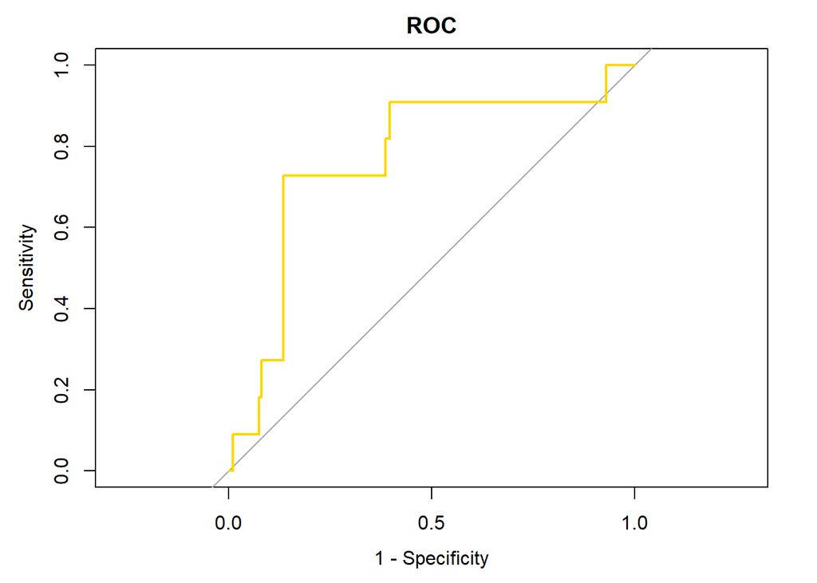

```
## Area under the curve: 0.7677
```

```
## Confusion Matrix and Statistics
##
##           Reference
## Prediction  No Yes
##        No  196  12
##        Yes   0   0
##
##                Accuracy : 0.9423
##                  95% CI : (0.9014, 0.9698)
##     No Information Rate : 0.9423
##     P-Value [Acc > NIR] : 0.575999
##
##                   Kappa : 0
##
##  Mcnemar's Test P-Value : 0.001496
##
##             Sensitivity : 0.00000
##             Specificity : 1.00000
##          Pos Pred Value :     NaN
##          Neg Pred Value : 0.94231
##              Prevalence : 0.05769
##          Detection Rate : 0.00000
##    Detection Prevalence : 0.00000
##       Balanced Accuracy : 0.50000
##
##        'Positive' Class : Yes
##
```

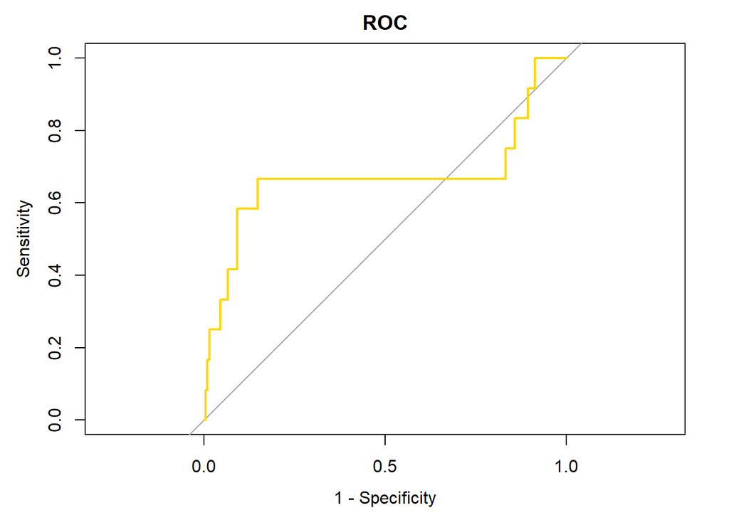

```
## Area under the curve: 0.6692
```

```
## Confusion Matrix and Statistics
##
##           Reference
## Prediction  No Yes
##        No  192  16
##        Yes   0   0
##
##                Accuracy : 0.9231
##                  95% CI : (0.8781, 0.9554)
##     No Information Rate : 0.9231
##     P-Value [Acc > NIR] : 0.5660154
##
##                   Kappa : 0
##
##  Mcnemar's Test P-Value : 0.0001768
##
##             Sensitivity : 0.00000
##             Specificity : 1.00000
##          Pos Pred Value :     NaN
##          Neg Pred Value : 0.92308
##              Prevalence : 0.07692
##          Detection Rate : 0.00000
##    Detection Prevalence : 0.00000
##       Balanced Accuracy : 0.50000
##
##        'Positive' Class : Yes
##
```

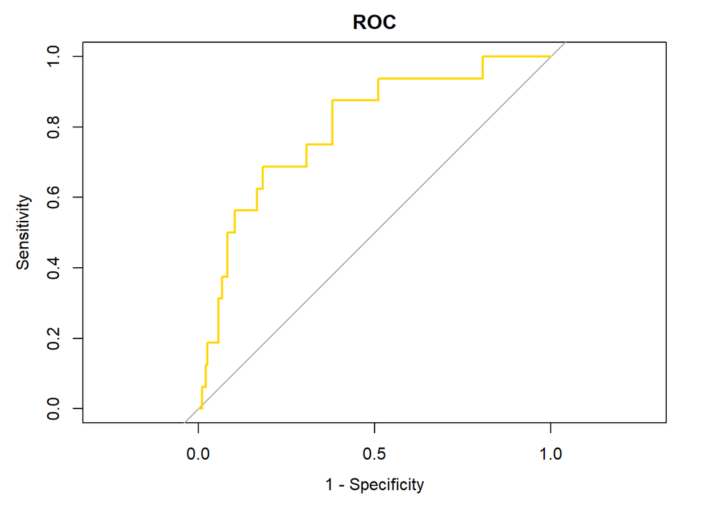

```
## Area under the curve: 0.7972
```

### glm

```
## Confusion Matrix and Statistics
##
##           Reference
## Prediction  No Yes
##        No  170  11
##        Yes   1   0
##
##                Accuracy : 0.9341
##                  95% CI : (0.8877, 0.9655)
##     No Information Rate : 0.9396
##     P-Value [Acc > NIR] : 0.692197
##
##                   Kappa : -0.0102
##
##  Mcnemar's Test P-Value : 0.009375
##
##             Sensitivity : 0.000000
##             Specificity : 0.994152
##          Pos Pred Value : 0.000000
##          Neg Pred Value : 0.939227
##              Prevalence : 0.060440
##          Detection Rate : 0.000000
##    Detection Prevalence : 0.005495
##       Balanced Accuracy : 0.497076
##
##        'Positive' Class : Yes
##
```

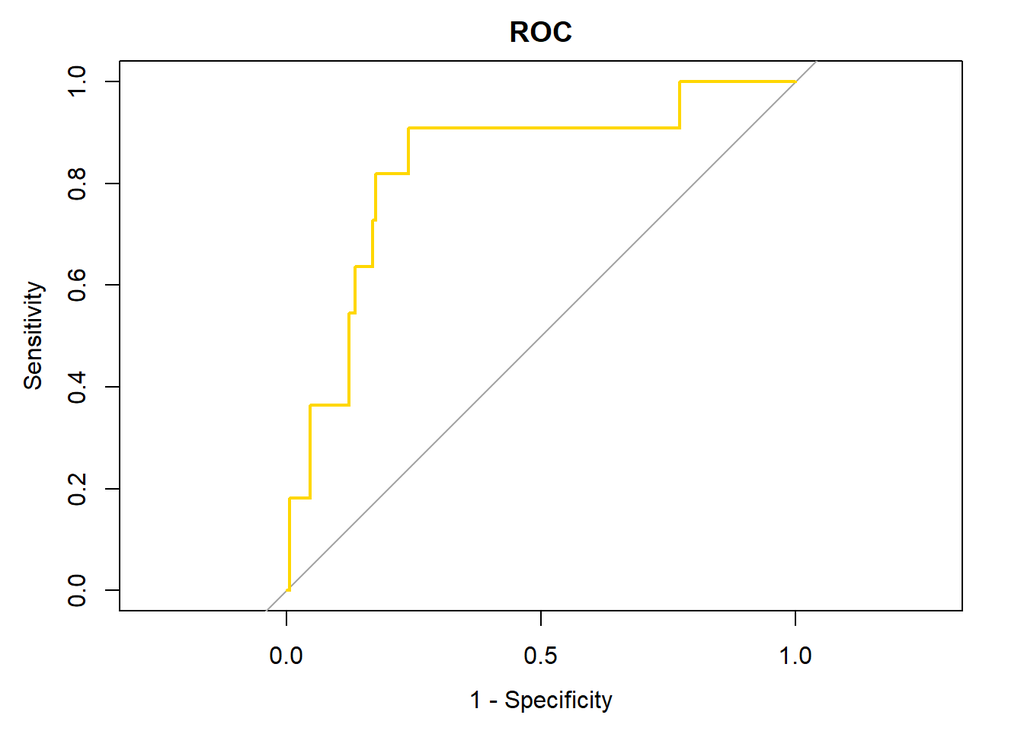

```
## Area under the curve: 0.8325
```

```
## Confusion Matrix and Statistics
##
##           Reference
## Prediction  No Yes
##        No  196  12
##        Yes   0   0
##
##                Accuracy : 0.9423
##                  95% CI : (0.9014, 0.9698)
##     No Information Rate : 0.9423
##     P-Value [Acc > NIR] : 0.575999
##
##                   Kappa : 0
##
##  Mcnemar's Test P-Value : 0.001496
##
##             Sensitivity : 0.00000
##             Specificity : 1.00000
##          Pos Pred Value :     NaN
##          Neg Pred Value : 0.94231
##              Prevalence : 0.05769
##          Detection Rate : 0.00000
##    Detection Prevalence : 0.00000
##       Balanced Accuracy : 0.50000
##
##        'Positive' Class : Yes
##
```

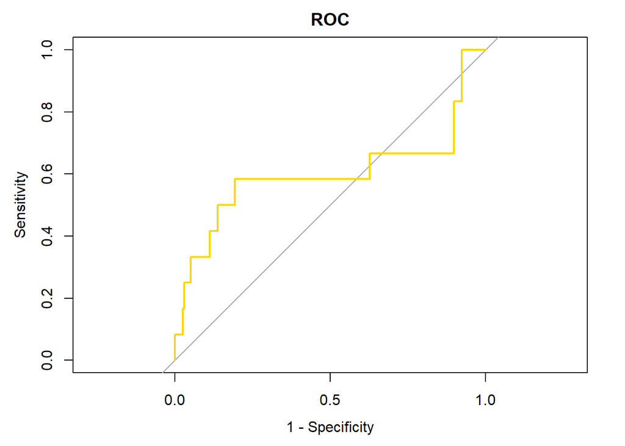

```
## Area under the curve: 0.5982
```

```
## Confusion Matrix and Statistics
##
##           Reference
## Prediction  No Yes
##        No  192  13
##        Yes   0   3
##
##                Accuracy : 0.9375
##                  95% CI : (0.8955, 0.9663)
##     No Information Rate : 0.9231
##     P-Value [Acc > NIR] : 0.2647027
##
##                   Kappa : 0.2988
##
##  Mcnemar's Test P-Value : 0.0008741
##
##             Sensitivity : 0.18750
##             Specificity : 1.00000
##          Pos Pred Value : 1.00000
##          Neg Pred Value : 0.93659
##              Prevalence : 0.07692
##          Detection Rate : 0.01442
##    Detection Prevalence : 0.01442
##       Balanced Accuracy : 0.59375
##
##        'Positive' Class : Yes
##
```

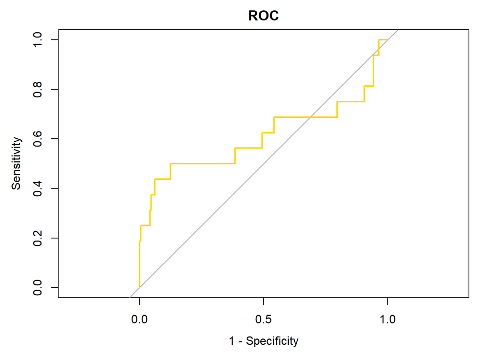

```
## Area under the curve: 0.609
```

#### glm / granica odcięcia 5%

```
## Confusion Matrix and Statistics
##
##           Reference
## Prediction No Yes
##        No  78   1
##        Yes 93  10
##
##                Accuracy : 0.4835
##                  95% CI : (0.409, 0.5586)
##     No Information Rate : 0.9396
##     P-Value [Acc > NIR] : 1
##
##                   Kappa : 0.0743
##
##  Mcnemar's Test P-Value : <2e-16
##
##             Sensitivity : 0.90909
##             Specificity : 0.45614
##          Pos Pred Value : 0.09709
##          Neg Pred Value : 0.98734
##              Prevalence : 0.06044
##          Detection Rate : 0.05495
##    Detection Prevalence : 0.56593
##       Balanced Accuracy : 0.68262
##
##        'Positive' Class : Yes
##
```

```
## Confusion Matrix and Statistics
##
##           Reference
## Prediction  No Yes
##        No  123   5
##        Yes  73   7
##
##                Accuracy : 0.625
##                  95% CI : (0.5554, 0.691)
##     No Information Rate : 0.9423
##     P-Value [Acc > NIR] : 1
##
##                   Kappa : 0.0576
##
##  Mcnemar's Test P-Value : 3.293e-14
##
##             Sensitivity : 0.58333
##             Specificity : 0.62755
##          Pos Pred Value : 0.08750
##          Neg Pred Value : 0.96094
##              Prevalence : 0.05769
##          Detection Rate : 0.03365
##    Detection Prevalence : 0.38462
##       Balanced Accuracy : 0.60544
##
##        'Positive' Class : Yes
##
```

```
## Confusion Matrix and Statistics
##
##           Reference
## Prediction  No Yes
##        No  122   8
##        Yes  70   8
##
##                Accuracy : 0.625
##                  95% CI : (0.5554, 0.691)
##     No Information Rate : 0.9231
##     P-Value [Acc > NIR] : 1
##
##                   Kappa : 0.0488
##
##  Mcnemar's Test P-Value : 4.954e-12
##
##             Sensitivity : 0.50000
##             Specificity : 0.63542
##          Pos Pred Value : 0.10256
##          Neg Pred Value : 0.93846
##              Prevalence : 0.07692
##          Detection Rate : 0.03846
##    Detection Prevalence : 0.37500
##       Balanced Accuracy : 0.56771
##
##        'Positive' Class : Yes
##
```

#### glm / granica odcięcia 3%

```
## Confusion Matrix and Statistics
##
##           Reference
## Prediction  No Yes
##        No    5   0
##        Yes 166  11
##
##                Accuracy : 0.0879
##                  95% CI : (0.0511, 0.1388)
##     No Information Rate : 0.9396
##     P-Value [Acc > NIR] : 1
##
##                   Kappa : 0.0036
##
##  Mcnemar's Test P-Value : <2e-16
##
##             Sensitivity : 1.00000
##             Specificity : 0.02924
##          Pos Pred Value : 0.06215
##          Neg Pred Value : 1.00000
##              Prevalence : 0.06044
##          Detection Rate : 0.06044
##    Detection Prevalence : 0.97253
##       Balanced Accuracy : 0.51462
##
##        'Positive' Class : Yes
##
```

```
## Confusion Matrix and Statistics
##
##           Reference
## Prediction  No Yes
##        No   11   0
##        Yes 185  12
##
##                Accuracy : 0.1106
##                  95% CI : (0.0714, 0.1613)
##     No Information Rate : 0.9423
##     P-Value [Acc > NIR] : 1
##
##                   Kappa : 0.0068
##
##  Mcnemar's Test P-Value : <2e-16
##
##             Sensitivity : 1.00000
##             Specificity : 0.05612
##          Pos Pred Value : 0.06091
##          Neg Pred Value : 1.00000
##              Prevalence : 0.05769
##          Detection Rate : 0.05769
##    Detection Prevalence : 0.94712
##       Balanced Accuracy : 0.52806
##
##        'Positive' Class : Yes
##
```

```
## Confusion Matrix and Statistics
##
##           Reference
## Prediction  No Yes
##        No   48   5
##        Yes 144  11
##
##                Accuracy : 0.2837
##                  95% CI : (0.2235, 0.3501)
##     No Information Rate : 0.9231
##     P-Value [Acc > NIR] : 1
##
##                   Kappa : -0.0125
##
##  Mcnemar's Test P-Value : <2e-16
##
##             Sensitivity : 0.68750
##             Specificity : 0.25000
##          Pos Pred Value : 0.07097
##          Neg Pred Value : 0.90566
##              Prevalence : 0.07692
##          Detection Rate : 0.05288
##    Detection Prevalence : 0.74519
##       Balanced Accuracy : 0.46875
##
##        'Positive' Class : Yes
##
```

### glmnet

```
## Confusion Matrix and Statistics
##
##           Reference
## Prediction  No Yes
##        No  171  11
##        Yes   0   0
##
##                Accuracy : 0.9396
##                  95% CI : (0.8944, 0.9694)
##     No Information Rate : 0.9396
##     P-Value [Acc > NIR] : 0.579305
##
##                   Kappa : 0
##
##  Mcnemar's Test P-Value : 0.002569
##
##             Sensitivity : 0.00000
##             Specificity : 1.00000
##          Pos Pred Value :     NaN
##          Neg Pred Value : 0.93956
##              Prevalence : 0.06044
##          Detection Rate : 0.00000
##    Detection Prevalence : 0.00000
##       Balanced Accuracy : 0.50000
##
##        'Positive' Class : Yes
##
```

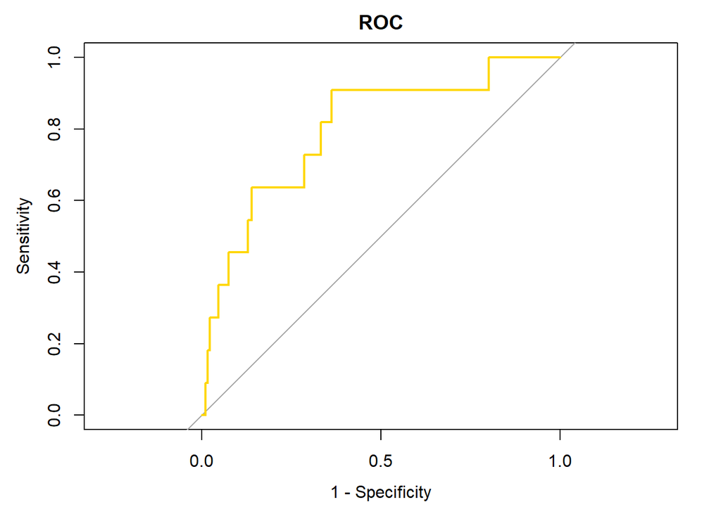

```
## Area under the curve: 0.7974
```

```
## Confusion Matrix and Statistics
##
##           Reference
## Prediction  No Yes
##        No  196  12
##        Yes   0   0
##
##                Accuracy : 0.9423
##                  95% CI : (0.9014, 0.9698)
##     No Information Rate : 0.9423
##     P-Value [Acc > NIR] : 0.575999
##
##                   Kappa : 0
##
##  Mcnemar's Test P-Value : 0.001496
##
##             Sensitivity : 0.00000
##             Specificity : 1.00000
##          Pos Pred Value :     NaN
##          Neg Pred Value : 0.94231
##              Prevalence : 0.05769
##          Detection Rate : 0.00000
##    Detection Prevalence : 0.00000
##       Balanced Accuracy : 0.50000
##
##        'Positive' Class : Yes
##
```

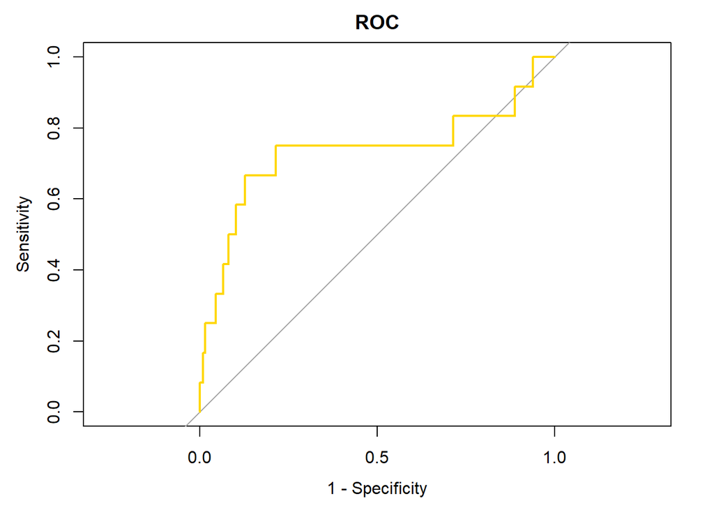

```
## Area under the curve: 0.733
```

```
## Confusion Matrix and Statistics
##
##           Reference
## Prediction  No Yes
##        No  192  16
##        Yes   0   0
##
##                Accuracy : 0.9231
##                  95% CI : (0.8781, 0.9554)
##     No Information Rate : 0.9231
##     P-Value [Acc > NIR] : 0.5660154
##
##                   Kappa : 0
##
##  Mcnemar's Test P-Value : 0.0001768
##
##             Sensitivity : 0.00000
##             Specificity : 1.00000
##          Pos Pred Value :     NaN
##          Neg Pred Value : 0.92308
##              Prevalence : 0.07692
##          Detection Rate : 0.00000
##    Detection Prevalence : 0.00000
##       Balanced Accuracy : 0.50000
##
##        'Positive' Class : Yes
##
```

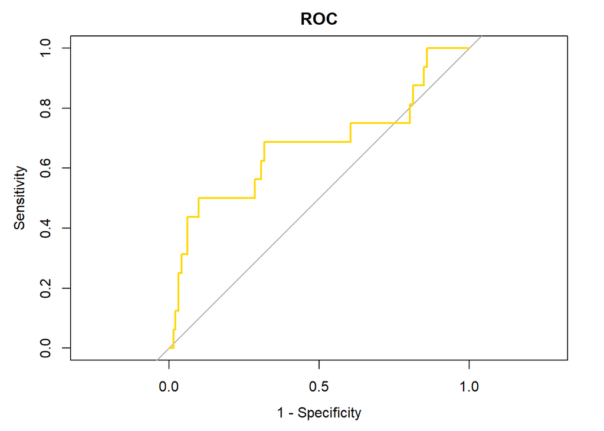

```
## Area under the curve: 0.6748
```

### nnet

```
## Confusion Matrix and Statistics
##
##           Reference
## Prediction  No Yes
##        No  171  11
##        Yes   0   0
##
##                Accuracy : 0.9396
##                  95% CI : (0.8944, 0.9694)
##     No Information Rate : 0.9396
##     P-Value [Acc > NIR] : 0.579305
##
##                   Kappa : 0
##
##  Mcnemar's Test P-Value : 0.002569
##
##             Sensitivity : 0.00000
##             Specificity : 1.00000
##          Pos Pred Value :     NaN
##          Neg Pred Value : 0.93956
##              Prevalence : 0.06044
##          Detection Rate : 0.00000
##    Detection Prevalence : 0.00000
##       Balanced Accuracy : 0.50000
##
##        'Positive' Class : Yes
##
```

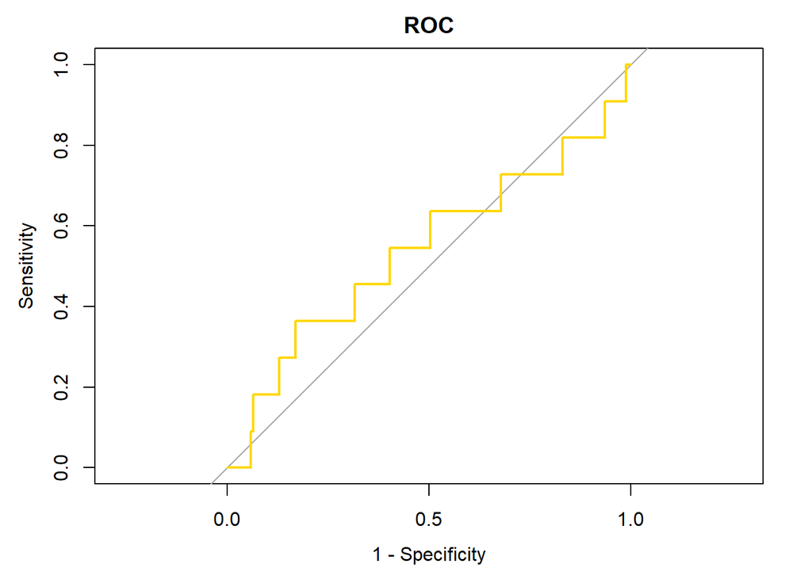

```
## Area under the curve: 0.5385
```

```
## Confusion Matrix and Statistics
##
##           Reference
## Prediction  No Yes
##        No  196  12
##        Yes   0   0
##
##                Accuracy : 0.9423
##                  95% CI : (0.9014, 0.9698)
##     No Information Rate : 0.9423
##     P-Value [Acc > NIR] : 0.575999
##
##                   Kappa : 0
##
##  Mcnemar's Test P-Value : 0.001496
##
##             Sensitivity : 0.00000
##             Specificity : 1.00000
##          Pos Pred Value :     NaN
##          Neg Pred Value : 0.94231
##              Prevalence : 0.05769
##          Detection Rate : 0.00000
##    Detection Prevalence : 0.00000
##       Balanced Accuracy : 0.50000
##
##        'Positive' Class : Yes
##
```

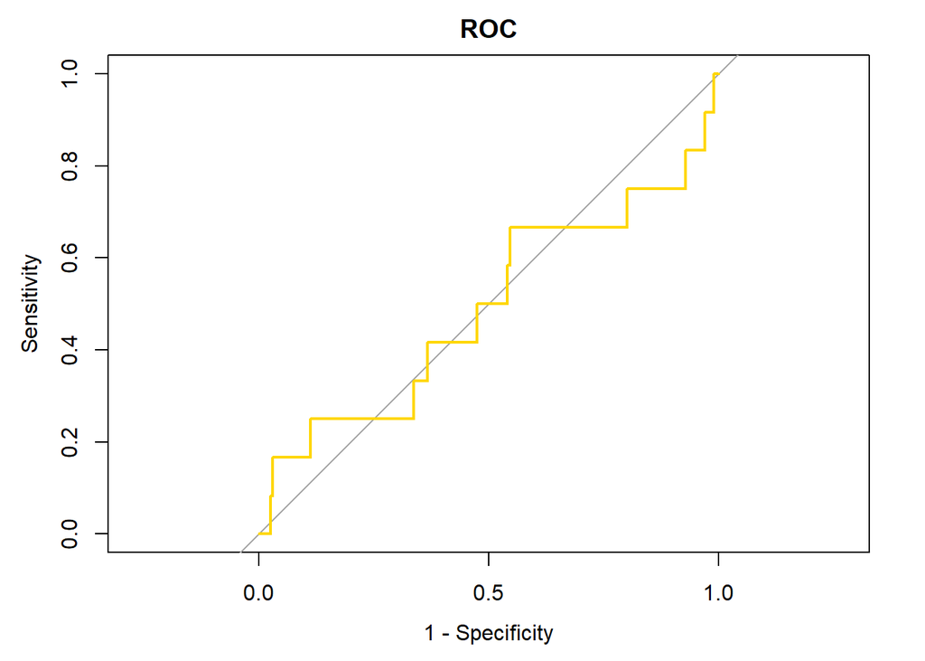

```
## Area under the curve: 0.4898
```

```
## Confusion Matrix and Statistics
##
##           Reference
## Prediction  No Yes
##        No  192  16
##        Yes   0   0
##
##                Accuracy : 0.9231
##                  95% CI : (0.8781, 0.9554)
##     No Information Rate : 0.9231
##     P-Value [Acc > NIR] : 0.5660154
##
##                   Kappa : 0
##
##  Mcnemar's Test P-Value : 0.0001768
##
##             Sensitivity : 0.00000
##             Specificity : 1.00000
##          Pos Pred Value :     NaN
##          Neg Pred Value : 0.92308
##              Prevalence : 0.07692
##          Detection Rate : 0.00000
##    Detection Prevalence : 0.00000
##       Balanced Accuracy : 0.50000
##
##        'Positive' Class : Yes
##
```

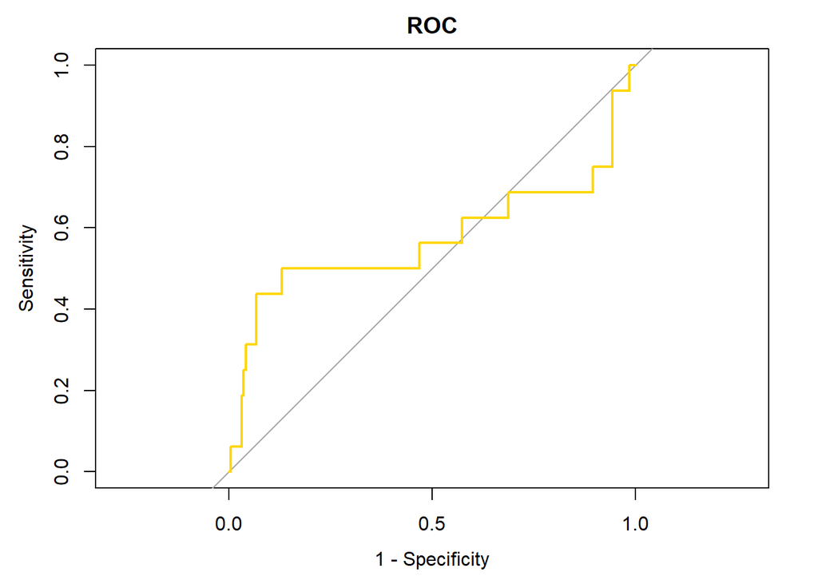

```
## Area under the curve: 0.5719
```

### gbm

```
## Confusion Matrix and Statistics
##
##           Reference
## Prediction  No Yes
##        No  169  11
##        Yes   2   0
##
##                Accuracy : 0.9286
##                  95% CI : (0.881, 0.9614)
##     No Information Rate : 0.9396
##     P-Value [Acc > NIR] : 0.7872
##
##                   Kappa : -0.0189
##
##  Mcnemar's Test P-Value : 0.0265
##
##             Sensitivity : 0.00000
##             Specificity : 0.98830
##          Pos Pred Value : 0.00000
##          Neg Pred Value : 0.93889
##              Prevalence : 0.06044
##          Detection Rate : 0.00000
##    Detection Prevalence : 0.01099
##       Balanced Accuracy : 0.49415
##
##        'Positive' Class : Yes
##
```

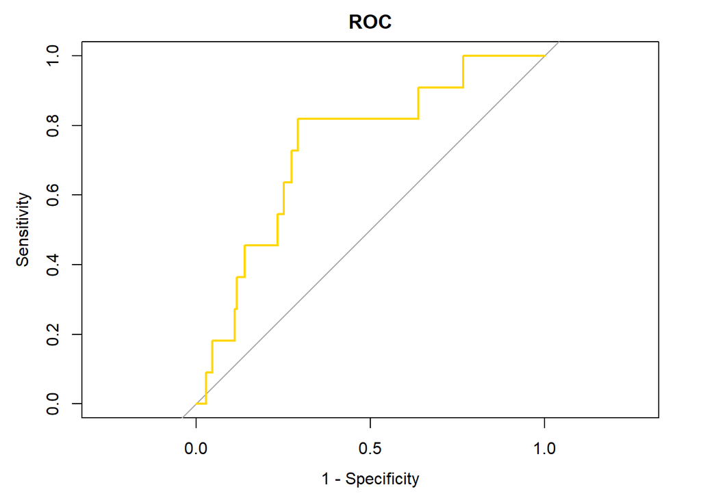

```
## Area under the curve: 0.7363
```

```
## Confusion Matrix and Statistics
##
##           Reference
## Prediction  No Yes
##        No  196  12
##        Yes   0   0
##
##                Accuracy : 0.9423
##                  95% CI : (0.9014, 0.9698)
##     No Information Rate : 0.9423
##     P-Value [Acc > NIR] : 0.575999
##
##                   Kappa : 0
##
##  Mcnemar's Test P-Value : 0.001496
##
##             Sensitivity : 0.00000
##             Specificity : 1.00000
##          Pos Pred Value :     NaN
##          Neg Pred Value : 0.94231
##              Prevalence : 0.05769
##          Detection Rate : 0.00000
##    Detection Prevalence : 0.00000
##       Balanced Accuracy : 0.50000
##
##        'Positive' Class : Yes
##
```

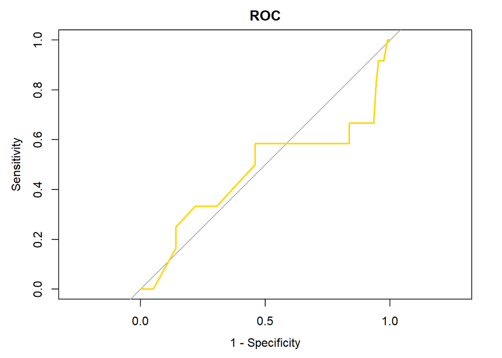

```
## Area under the curve: 0.4677
```

```
## Confusion Matrix and Statistics
##
##           Reference
## Prediction  No Yes
##        No  190  16
##        Yes   2   0
##
##                Accuracy : 0.9135
##                  95% CI : (0.8667, 0.9479)
##     No Information Rate : 0.9231
##     P-Value [Acc > NIR] : 0.749148
##
##                   Kappa : -0.0174
##
##  Mcnemar's Test P-Value : 0.002183
##
##             Sensitivity : 0.000000
##             Specificity : 0.989583
##          Pos Pred Value : 0.000000
##          Neg Pred Value : 0.922330
##              Prevalence : 0.076923
##          Detection Rate : 0.000000
##    Detection Prevalence : 0.009615
##       Balanced Accuracy : 0.494792
##
##        'Positive' Class : Yes
##
```

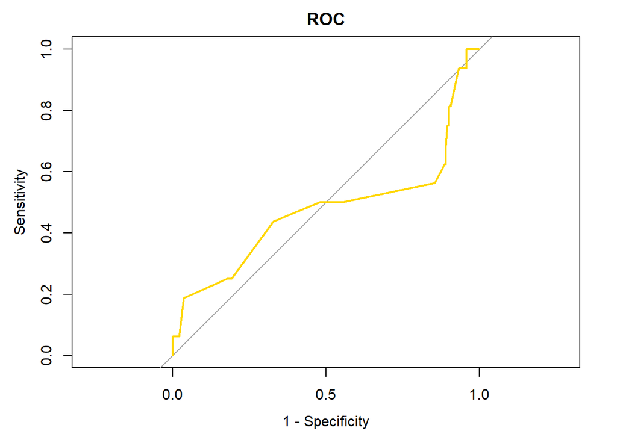

```
## Area under the curve: 0.4748
```

### SVM - Jądro Gaussowskie

```
## Confusion Matrix and Statistics
##
##           Reference
## Prediction  No Yes
##        No  171  11
##        Yes   0   0
##
##                Accuracy : 0.9396
##                  95% CI : (0.8944, 0.9694)
##     No Information Rate : 0.9396
##     P-Value [Acc > NIR] : 0.579305
##
##                   Kappa : 0
##
##  Mcnemar's Test P-Value : 0.002569
##
##             Sensitivity : 0.00000
##             Specificity : 1.00000
##          Pos Pred Value :     NaN
##          Neg Pred Value : 0.93956
##              Prevalence : 0.06044
##          Detection Rate : 0.00000
##    Detection Prevalence : 0.00000
##       Balanced Accuracy : 0.50000
##
##        'Positive' Class : Yes
##
```

```
## Confusion Matrix and Statistics
##
##           Reference
## Prediction  No Yes
##        No  196  12
##        Yes   0   0
##
##                Accuracy : 0.9423
##                  95% CI : (0.9014, 0.9698)
##     No Information Rate : 0.9423
##     P-Value [Acc > NIR] : 0.575999
##
##                   Kappa : 0
##
##  Mcnemar's Test P-Value : 0.001496
##
##             Sensitivity : 0.00000
##             Specificity : 1.00000
##          Pos Pred Value :     NaN
##          Neg Pred Value : 0.94231
##              Prevalence : 0.05769
##          Detection Rate : 0.00000
##    Detection Prevalence : 0.00000
##       Balanced Accuracy : 0.50000
##
##        'Positive' Class : Yes
##
```

```
## Confusion Matrix and Statistics
##
##           Reference
## Prediction  No Yes
##        No  192  16
##        Yes   0   0
##
##                Accuracy : 0.9231
##                  95% CI : (0.8781, 0.9554)
##     No Information Rate : 0.9231
##     P-Value [Acc > NIR] : 0.5660154
##
##                   Kappa : 0
##
##  Mcnemar's Test P-Value : 0.0001768
##
##             Sensitivity : 0.00000
##             Specificity : 1.00000
##          Pos Pred Value :     NaN
##          Neg Pred Value : 0.92308
##              Prevalence : 0.07692
##          Detection Rate : 0.00000
##    Detection Prevalence : 0.00000
##       Balanced Accuracy : 0.50000
##
##        'Positive' Class : Yes
##
```

### SVM - Jądro Wielomianowe

```
## Confusion Matrix and Statistics
##
##           Reference
## Prediction  No Yes
##        No  171  11
##        Yes   0   0
##
##                Accuracy : 0.9396
##                  95% CI : (0.8944, 0.9694)
##     No Information Rate : 0.9396
##     P-Value [Acc > NIR] : 0.579305
##
##                   Kappa : 0
##
##  Mcnemar's Test P-Value : 0.002569
##
##             Sensitivity : 0.00000
##             Specificity : 1.00000
##          Pos Pred Value :     NaN
##          Neg Pred Value : 0.93956
##              Prevalence : 0.06044
##          Detection Rate : 0.00000
##    Detection Prevalence : 0.00000
##       Balanced Accuracy : 0.50000
##
##        'Positive' Class : Yes
##
```

```
## Confusion Matrix and Statistics
##
##           Reference
## Prediction  No Yes
##        No  196  12
##        Yes   0   0
##
##                Accuracy : 0.9423
##                  95% CI : (0.9014, 0.9698)
##     No Information Rate : 0.9423
##     P-Value [Acc > NIR] : 0.575999
##
##                   Kappa : 0
##
##  Mcnemar's Test P-Value : 0.001496
##
##             Sensitivity : 0.00000
##             Specificity : 1.00000
##          Pos Pred Value :     NaN
##          Neg Pred Value : 0.94231
##              Prevalence : 0.05769
##          Detection Rate : 0.00000
##    Detection Prevalence : 0.00000
##       Balanced Accuracy : 0.50000
##
##        'Positive' Class : Yes
##
```

```
## Confusion Matrix and Statistics
##
##           Reference
## Prediction  No Yes
##        No  192  16
##        Yes   0   0
##
##                Accuracy : 0.9231
##                  95% CI : (0.8781, 0.9554)
##     No Information Rate : 0.9231
##     P-Value [Acc > NIR] : 0.5660154
##
##                   Kappa : 0
##
##  Mcnemar's Test P-Value : 0.0001768
##
##             Sensitivity : 0.00000
##             Specificity : 1.00000
##          Pos Pred Value :     NaN
##          Neg Pred Value : 0.92308
##              Prevalence : 0.07692
##          Detection Rate : 0.00000
##    Detection Prevalence : 0.00000
##       Balanced Accuracy : 0.50000
##
##        'Positive' Class : Yes
##
```

## Zestawienie modeli i technik imputacji

Porównaliśmy metryki Accuracy/AUC:

**Las losowy ranger:**

1. 0.9396/0.7677
2. **0.9423**/0.6692
3. 0.9231/0.7972

**Regresja logistyczna:**

1. 0.9341/**0.8325** # największe AUC!
2. **0.9423**/0.5982
3. 0.9375/0.609

**Regresja logistyczna lasso/ridge:**

1. 0.9396/0.7974
2. **0.9423**/0.733
3. 0.9231/0.6748

**Sieć neuronowa:**

1. 0.9396/0.5385
2. **0.9423**/0.4898
3. 0.9231/0.5719

**Gradient Boosting Machines:**

1. 0.9286/0.7363
2. **0.9423**/0.4677
3. 0.9231/0.4748

**Support Vector Machines - Gaussowskie jądro:**

**Support Vector Machines - Wielomianowe jądro:**

# Wnioski - najlepszy model i technika imputacji

Z powyższych wyników widać, że Accuracy nie jest najlepszą metryką do porównywania modeli. Każdy model osiągnął to samo maksymalne Accuracy dla imputacji k-Nearest Neighbors. Porównamy więc za pomocą AUC.

Warto podkreślić, że większość modeli ma Sensitivity = 0, co dla naszego zadania medycznego jest dużym błędem, bo nie wykryliśmy żadnego chorego. Tylko **model regresji logistycznej glm** wykrywał chorych przy progu odcięcia 50%. Z tego też powodu umieściliśmy progi odcięcia dla 5% i 3%, które zwiększyły znacznie wartość Sensitivity (wykrytych chorych). Próg 5% zachowywał jeszcze przy tym rozsądne Accuracy.

Z powyższych wyników można by wnioskować, że najlepiej poradził sobie model **regresji logistycznej** dla techniki imputacji **usuwanie obserwacji**.

Najlepsze sprawdziły się techniki imputacji: **usuwanie obserwacji** oraz **trzeci level dla NA**.

W predykcjach medycznych ważne jest wykrywanie przypadków chprych, czyli pozytywnych - “Yes”. Z tego powodu najlepiej jest obniżyć próg wykrywania takich przypadków. Natomiast wśród naszych modeli najlepiej pozytywne przypadki wykrywał model **regresji logistycznej**. Pokazaliśmy nawet progi 3-5% dla których następuje znaczny skok liczby wykrytych przypadków ‘Yes’.

W związku z powyższym wydaje nam się najlepszy model + technika imputacji: